# Explore_bikeshare_data

### Explore Bike Share Data

For this project, your goal is to ask and answer three questions about the available bikeshare data from Washington, Chicago, and New York. This notebook can be submitted directly through the workspace when you are confident in your results.

```r
# Importing the package to combine datasets.
# Wickham, H., & Grolemund, G. (2016). R for Data Science. O'Reilly Publishing.

library(dplyr)
library(ggplot2)
```

```r
# Importing the needed datasets and making them into a dataframe.

ny = read.csv('new_york_city.csv')
wash = read.csv('washington.csv')
chi = read.csv('chicago.csv')
```

```r
# displaying the first rows

head(ny)
```

| X | Start.Time | End.Time | Trip.Duration | Start.Station | End.Station | User.Type | Gender | Birth.Year |
| --- | --- | --- | --- | --- | --- | --- | --- | --- |
| 5688089 | 2017-06-11 14:55:05 | 2017-06-11 15:08:21 | 795 | Suffolk St & Stanton St | W Broadway & Spring St | Subscriber | Male | 1998 |
| 4096714 | 2017-05-11 15:30:11 | 2017-05-11 15:41:43 | 692 | Lexington Ave & E 63 St | 1 Ave & E 78 St | Subscriber | Male | 1981 |
| 2173887 | 2017-03-29 13:26:26 | 2017-03-29 13:48:31 | 1325 | 1 Pl & Clinton St | Henry St & Degraw St | Subscriber | Male | 1987 |
| 3945638 | 2017-05-08 19:47:18 | 2017-05-08 19:59:01 | 703 | Barrow St & Hudson St | W 20 St & 8 Ave | Subscriber | Female | 1986 |
| 6208972 | 2017-06-21 07:49:16 | 2017-06-21 07:54:46 | 329 | 1 Ave & E 44 St | E 53 St & 3 Ave | Subscriber | Male | 1992 |
| 1285652 | 2017-02-22 18:55:24 | 2017-02-22 19:12:03 | 998 | State St & Smith St | Bond St & Fulton St | Subscriber | Male | 1986 |

```r
head(wash)
```

| X | Start.Time | End.Time | Trip.Duration | Start.Station | End.Station | User.Type |
| --- | --- | --- | --- | --- | --- | --- |
| 1621326 | 2017-06-21 08:36:34 | 2017-06-21 08:44:43 | 489.066 | 14th & Belmont St NW | 15th & K St NW | Subscriber |
| 482740 | 2017-03-11 10:40:00 | 2017-03-11 10:46:00 | 402.549 | Yuma St & Tenley Circle NW | Connecticut Ave & Yuma St NW | Subscriber |
| 1330037 | 2017-05-30 01:02:59 | 2017-05-30 01:13:37 | 637.251 | 17th St & Massachusetts Ave NW | 5th & K St NW | Subscriber |
| 665458 | 2017-04-02 07:48:35 | 2017-04-02 08:19:03 | 1827.341 | Constitution Ave & 2nd St NW/DOL | M St & Pennsylvania Ave NW | Customer |
| 1481135 | 2017-06-10 08:36:28 | 2017-06-10 09:02:17 | 1549.427 | Henry Bacon Dr & Lincoln Memorial Circle NW | Maine Ave & 7th St SW | Subscriber |
| 1148202 | 2017-05-14 07:18:18 | 2017-05-14 07:24:56 | 398.000 | 1st & K St SE | Eastern Market Metro / Pennsylvania Ave & 7th St SE | Subscriber |

```r
head(chi)
```

| X | Start.Time | End.Time | Trip.Duration | Start.Station | End.Station | User.Type | Gender | Birth.Year |
| --- | --- | --- | --- | --- | --- | --- | --- | --- |
| 1423854 | 2017-06-23 15:09:32 | 2017-06-23 15:14:53 | 321 | Wood St & Hubbard St | Damen Ave & Chicago Ave | Subscriber | Male | 1992 |
| 955915 | 2017-05-25 18:19:03 | 2017-05-25 18:45:53 | 1610 | Theater on the Lake | Sheffield Ave & Waveland Ave | Subscriber | Female | 1992 |
| 9031 | 2017-01-04 08:27:49 | 2017-01-04 08:34:45 | 416 | May St & Taylor St | Wood St & Taylor St | Subscriber | Male | 1981 |
| 304487 | 2017-03-06 13:49:38 | 2017-03-06 13:55:28 | 350 | Christiana Ave & Lawrence Ave | St. Louis Ave & Balmoral Ave | Subscriber | Male | 1986 |
| 45207 | 2017-01-17 14:53:07 | 2017-01-17 15:02:01 | 534 | Clark St & Randolph St | Desplaines St & Jackson Blvd | Subscriber | Male | 1975 |
| 1473887 | 2017-06-26 09:01:20 | 2017-06-26 09:11:06 | 586 | Clinton St & Washington Blvd | Canal St & Taylor St | Subscriber | Male | 1990 |

```r
# Displaying the shape or dimensions of the dataframes.

dim(ny)
```

1. 54770

2. 9

```r
dim(wash)
```

1. 89051

2. 7

```r
dim(chi)
```

1. 8630

2. 9

```r
# Adding the number of rows from each dataframe as a check for the combined datasets.

total_rows = dim(ny)[1] + dim(wash)[1] + dim(chi)[1]
total_rows
```

152451

```r
# Combining the three datasets into one dataframe and finding the dimensions.
# Wickham, H., & Grolemund, G. (2016). R for Data Science. O'Reilly Publishing.

combined_df = bind_rows(chi, wash, ny)
```

```r
# Displaying the first rows of the combined dataframe.

head(combined_df)
```

| X | Start.Time | End.Time | Trip.Duration | Start.Station | End.Station | User.Type | Gender | Birth.Year |
| --- | --- | --- | --- | --- | --- | --- | --- | --- |
| 1423854 | 2017-06-23 15:09:32 | 2017-06-23 15:14:53 | 321 | Wood St & Hubbard St | Damen Ave & Chicago Ave | Subscriber | Male | 1992 |
| 955915 | 2017-05-25 18:19:03 | 2017-05-25 18:45:53 | 1610 | Theater on the Lake | Sheffield Ave & Waveland Ave | Subscriber | Female | 1992 |
| 9031 | 2017-01-04 08:27:49 | 2017-01-04 08:34:45 | 416 | May St & Taylor St | Wood St & Taylor St | Subscriber | Male | 1981 |
| 304487 | 2017-03-06 13:49:38 | 2017-03-06 13:55:28 | 350 | Christiana Ave & Lawrence Ave | St. Louis Ave & Balmoral Ave | Subscriber | Male | 1986 |
| 45207 | 2017-01-17 14:53:07 | 2017-01-17 15:02:01 | 534 | Clark St & Randolph St | Desplaines St & Jackson Blvd | Subscriber | Male | 1975 |
| 1473887 | 2017-06-26 09:01:20 | 2017-06-26 09:11:06 | 586 | Clinton St & Washington Blvd | Canal St & Taylor St | Subscriber | Male | 1990 |

```r
# Finding the dimensions of the combined dataframe

combined_total_rows = dim(combined_df)
combined_total_rows
```

1. 152451

2. 9

```r
# Checking to make sure the sum of rows in each individual dataframe match the total rows in the combined dataframe.

total_rows - combined_total_rows[1]
```

0

### Question 1

**How do the User Types break down by city?**

```r
# Creating source items for the wrapper below
chi$source = "Chicago"
wash$source = "Washington"
ny$source = "New York"
combined_df$source = "'Total Customers"
```

```r
# Combinig all datasets to use in the data wrapper.
all_df = bind_rows(chi, wash, ny, combined_df)
```

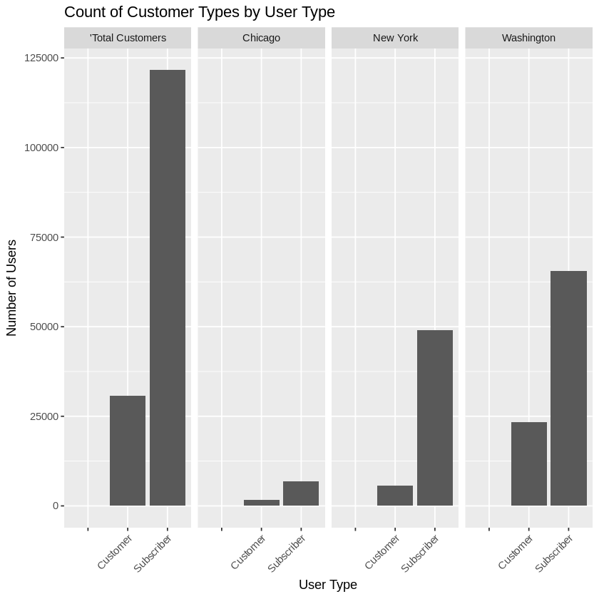

```r
# Creating a bar chart to compare the total number of subscribers and number by city.
ggplot(aes(x = User.Type), data = subset(all_df, !is.na(User.Type))) +
    geom_bar() +
    facet_wrap(~ source, ncol = 4) +
    ggtitle('Count of Customer Types by User Type') +
    xlab('User Type') +
    ylab('Number of Users') +
    theme(axis.text.x = element_text(angle = 45, hjust = 1))
```

```r
# Finding the number of Customers and Subscribers.
table(combined_df$User.Type)
```

```
             Customer Subscriber
       121      30754     121576
```

```r
table(chi$User.Type)
```

```
             Customer Subscriber
         1       1746       6883
```

```r
table(ny$User.Type)
```

```
             Customer Subscriber
       119       5558      49093
```

```r
table(wash$User.Type)
```

```
             Customer Subscriber
         1      23450      65600
```

**In all three cities the number of Subscribers is larger than the number of Customers. This leads to the next question of what is the proportion of Subscribers to users?**

### Question 2

**What proportion of User Types are Subscriber or Customers?**

```r
# Wickham, H., & Grolemund, G. (2016). R for Data Science. O'Reilly Publishing.
# Creating a function to print the proportion of Subscribers to the total.
calc_proportion_subscribers = function(data, city_name) {
    user_type_table = table(data$User.Type)
    proportion_subscribers = user_type_table['Subscriber'] / sum(user_type_table)
    print(sprintf('The proportion of subscribers from %s is %.2f%%', city_name, proportion_subscribers * 100))
}
```

```r
# Wickham, H., & Grolemund, G. (2016). R for Data Science. O'Reilly Publishing.
#Creating a function to create pie charts for the proportion of Subscribers and Customers.
create_pie_chart = function(df, city_name) {
    user_type_counts = df %>%
        filter(User.Type %in% c('Subscriber', 'Customer')) %>%
        group_by(User.Type) %>%
        summarise(count = n()) %>%
        mutate(percentage = count / sum(count) * 100)
    ggplot(user_type_counts, aes(x = "", y = percentage, fill = User.Type)) +
        geom_bar(stat = "identity", width = 1) +
        coord_polar(theta = "y") +
        labs(title = paste("Percentage of Subscribers and Customers in", city_name), x = "", y = "") +
        theme_void() +
        geom_text(aes(label = paste0(round(percentage, 1), "%")),
              position = position_stack(vjust = 0.5))
}
```

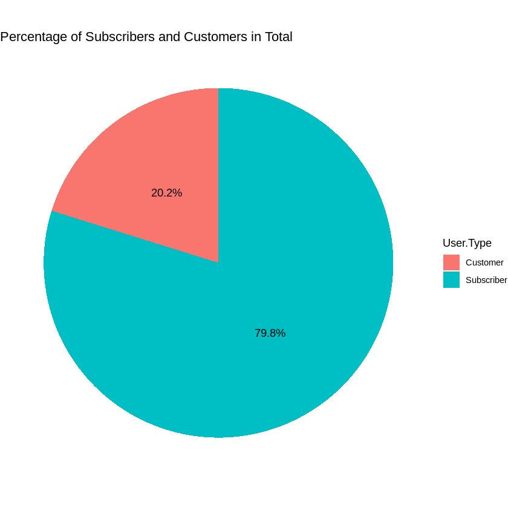

```r
create_pie_chart(combined_df, 'Total')
```

```r
calc_proportion_subscribers(combined_df, 'Total of all cities')
```

```
[1] "The proportion of subscribers from Total of all cities is 79.75%"
```

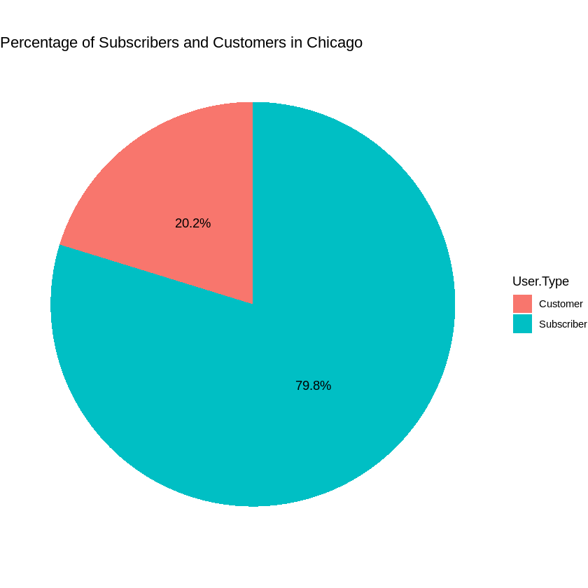

```r
create_pie_chart(chi, 'Chicago')
```

```r
calc_proportion_subscribers(chi, 'Chicago')
```

```
[1] "The proportion of subscribers from Chicago is 79.76%"
```

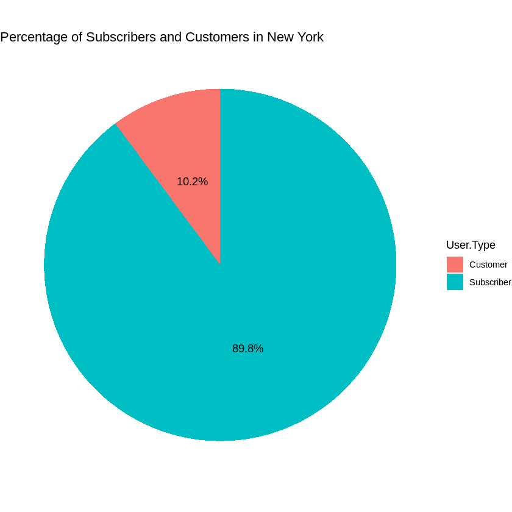

```r
create_pie_chart(ny, 'New York')
```

```r
calc_proportion_subscribers(ny, 'New York')
```

```
[1] "The proportion of subscribers from New York is 89.63%"
```

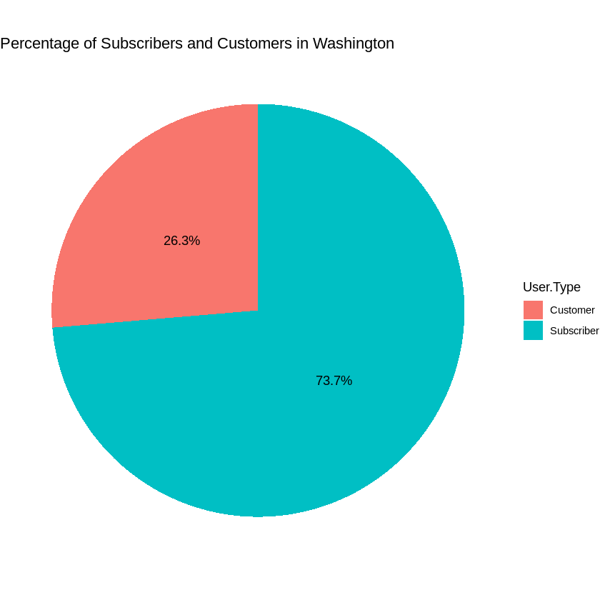

```r
create_pie_chart(wash, 'Washington')
```

```r
calc_proportion_subscribers(wash, 'Washington')
```

```
[1] "The proportion of subscribers from Washington is 73.67%"
```

**New York City has the largest proportion of Subscribers at 89.6%, while Washington has the smallest proportion of Subscribers at 73.7%. Chicago has the same proportion of Subscribers as all three datasets combined at 79.8%. This information could be useful to use with other information about the different users not found in this dataset, by comparing what is different about New York and Washington that there is a 15.9% difference in subscribers between the two.**

### Question 3

**What is the busiest day of the week for rentals broken down by city?**

```r
# Wickham, H., & Grolemund, G. (2016). R for Data Science. O'Reilly Publishing.
# Creating a function to create a histogram of number of rentals by day of week.
create_histogram = function(df, city_name) {
    df$Start.Time = as.POSIXct(df$Start.Time, format='%Y-%m-%d %H:%M:%S')
    df = df %>%
        mutate(day_of_week = weekdays(Start.Time))
    df$day_of_week = factor(df$day_of_week, levels = c('Sunday', 'Monday', 'Tuesday', 'Wednesday', 'Thursday', 'Friday', 'Saturday'))
    ggplot(df, aes(x = day_of_week)) +
        geom_histogram(stat = 'count', fill = 'blue', color = 'black') +
        labs(title = paste('Histogram of Rentals in', city_name, 'by Day of the Week'), x = 'Day of the Week', y = 'Number of Rentals')
}
```

```r
# Wickham, H., & Grolemund, G. (2016). R for Data Science. O'Reilly Publishing.
# Creating a function to create a table of number of rentals by day of week.
create_table = function(df, city_name) {
    df$Start.Time <- as.POSIXct(df$Start.Time, format='%Y-%m-%d %H:%M:%S')

    df <- df %>%
        mutate(day_of_week = weekdays(Start.Time))

    table_df = df %>%
        group_by(day_of_week) %>%
        summarise(Count = n()) %>%
        arrange(match(day_of_week, c('Sunday', 'Monday', 'Tuesday', 'Wednesday', 'Thursday', 'Friday', 'Saturday')))

    cat('Table of Rentals in', city_name, 'by Day of Week')
    print(table_df)

}
```

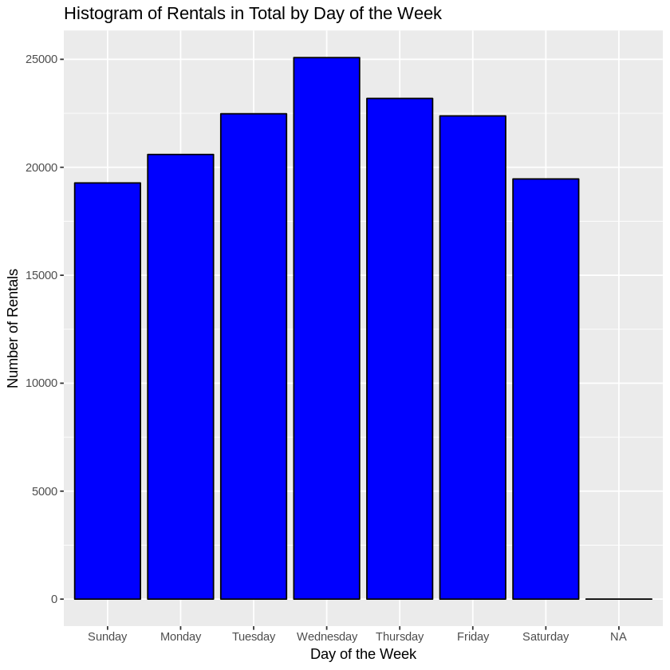

```r
create_histogram(combined_df, 'Total')
```

```r
create_table(combined_df, 'Total')
```

```
Table of Rentals in Total by Day of Week# A tibble: 8 x 2
  day_of_week Count
  <chr>       <int>
1 Sunday      19274
2 Monday      20593
3 Tuesday     22478
4 Wednesday   25080
5 Thursday    23187
6 Friday      22379
7 Saturday    19459
8 <NA>            1
```

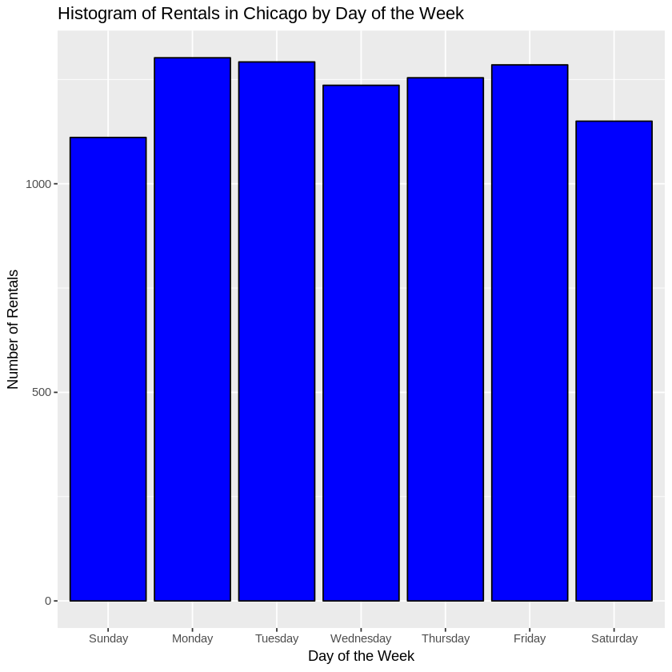

```r
create_histogram(chi, 'Chicago')
```

```r
create_table(chi, 'Chicago')
```

```
Table of Rentals in Chicago by Day of Week# A tibble: 7 x 2
  day_of_week Count
  <chr>       <int>
1 Sunday       1111
2 Monday       1302
3 Tuesday      1292
4 Wednesday    1236
5 Thursday     1254
6 Friday       1285
7 Saturday     1150
```

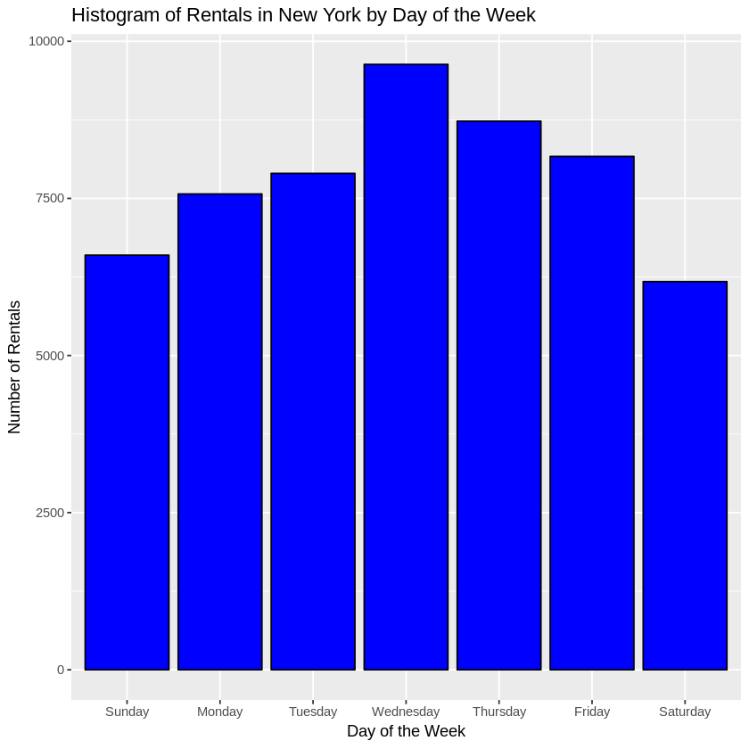

```r
create_histogram(ny, 'New York')
```

```r
create_table(ny, 'New York')
```

```
Table of Rentals in New York by Day of Week# A tibble: 7 x 2
  day_of_week Count
  <chr>       <int>
1 Sunday       6597
2 Monday       7570
3 Tuesday      7898
4 Wednesday    9632
5 Thursday     8729
6 Friday       8168
7 Saturday     6176
```

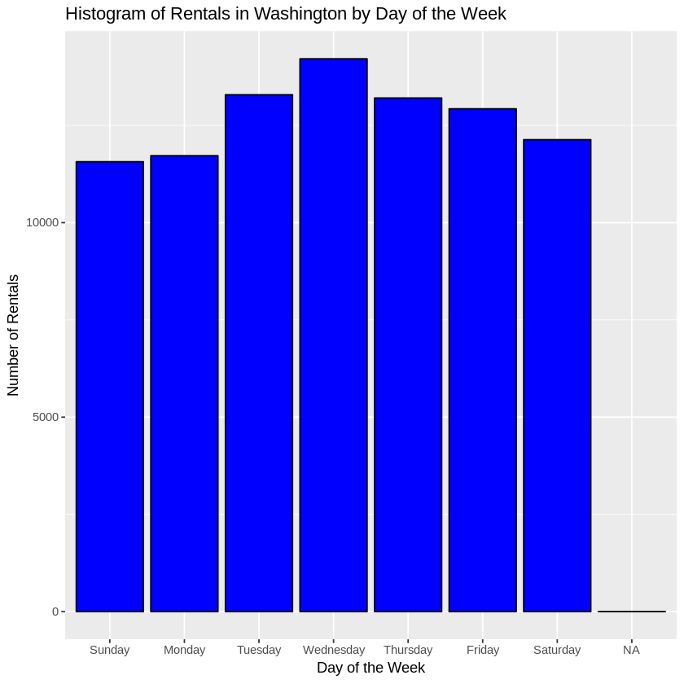

```r
create_histogram(wash, 'Washington')
```

```r
create_table(wash, 'Washington')
```

```
Table of Rentals in Washington by Day of Week# A tibble: 8 x 2
  day_of_week Count
  <chr>       <int>
1 Sunday      11566
2 Monday      11721
3 Tuesday     13288
4 Wednesday   14212
5 Thursday    13204
6 Friday      12926
7 Saturday    12133
8 <NA>            1
```

**Interestingly, all three cities have more rentals during the week than on the weekend. Wednesday is the highest rental day for both Washington, New York, while Monday is the busiest rental day and Wednesday is the lowest for rentals during the weekdays.**

```r
system('python -m nbconvert Explore_bikeshare_data.ipynb')
```